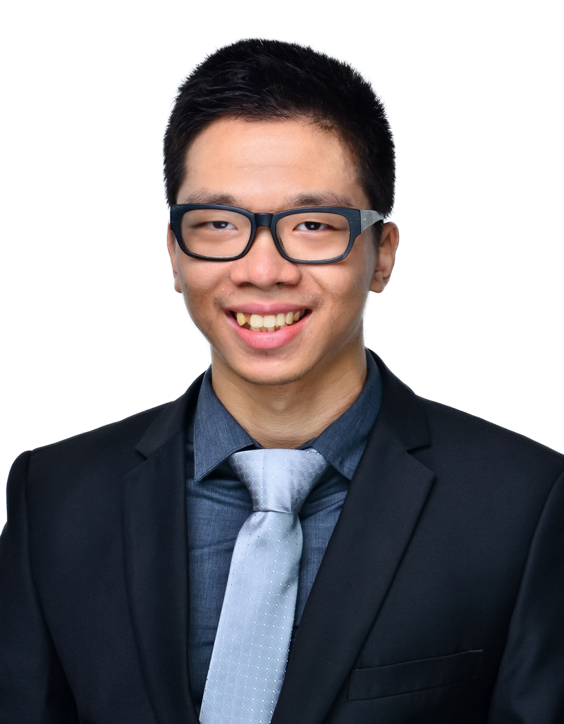

# Chuck Leong

## Executive Summary

A Science Bachelor degree holder in economics & finance of Politics & Economic School, University of London. Experienced in tutoring & teaching English 1 on 1 by achieving clients’ academic goals through personalised course programs. Producing & Proofreading academic English learning materials while keeping track of my clients’ progresses and maintaining a good client dynamic. I was able to help clients get a 7.0 IELTS score. I am skillful in using Microsoft software including Word, Excel and Powerpoint to boost my productivity. Besides English, I am also procifient in Mandarin Chinese and Cantonese.

## Education

2015.09-2018.06 | **B.S. in Economics & Finance** | University of London, United Kingdom

2013.10-2015.04 | **Diploma in Business Management** | Singapore Institute in Management, Singapore

## Work Experience

2024.03-2026.03 | **Online IELTS Tutor**

- Teaching students IELTS Academic / General Training online in private form or in small classes, covering English skills in listening, speaking, reading and writing. Customizing teaching plans for students according to their individuals’ learning ability and speed.
- Designing course programs and learning materials ranging from lecture notes, vocabulary sheets, grammar exercises, comprehension writing and oral mock exams.
- Diagnosing students’ capability in academic writing and speaking based on IELTS evaluation criteria and giving students critical feedback in order to improve their lexical accuracy, critical thinking capacity and grammatical cohesion.
- Assisted no less than 25 students improve English level from **A1~A2** to **B2~C1**; 22 of them managed to score **2.0 to 2.5 higher on average**.
- Produced 4 sets of learning materials while keeping a assessment completion rate at **95%** and **4 stars out of 5** in satisfactory level.

2022.03-2023.11 | **B2B Online Merchant Manager**

###### Guangzhou Chengfeng Brother Co., Ltd.

- Handling daily operation in online merchant by monitoring daily statistics in UV, PV, conversion rate and the rate of return in Google advertising.
- Maintaining current products’ life cycle: accuracy improvement in product information, traffic keywords, product pages.
- Building product databases for assisting sales department in offering quotation process and in turn improving conversion rate.
- Designing & deploying merchant’s landing page for promoting sales during company events’ period / Alibaba events’ period.
- Managed to **boost the star rating** of the merchant to **3 stars from 0 stars**.
- Achieved over 15000+ monthly unique views storewide and **increased 212.5%** in overall conversion rate to **2.5%** from 0.8% between ante-event & post-event period.

2021.01-2022.07 | **English Tutor**

###### Guangzhou Lixian Education & Training Centre

- Designing & Customizing study plans in English for primary & secondary students.
- Editing and writing lecture notes / learning materials individually for students’ in different school years accordingly.
- Initiating mock exams and assigning students assessments in order to keeping a close eye on their learning progress.
- Promoting my services to parents in the neighbourhood through the business expansion phase of the company.
- Facilitated over **60** clients ranging from second graders to students in secondary 2 in achieving a **higher average score** of 90 from that of 70 before my services.

## Skills

English

Microsoft Excel

Mandarin Cantonese

Microsoft Word

Computer Literacy

Microsoft Powerpoint